# NOAA Storm Data Report

Across US Excessive Heat and Flooding are biggest threats to Human and Economic health

Marcello Molinaro

## Synopsis

This research report uses the U.S. National Oceanic and Atmospheric Asministration’s (NOAA) storm database, compiled by the National Weather Service. It analyzes which storm event types are most harmful to:

- population health
- economic consequences

For this study, “Population Health” is a mesure of overall fatalities and injuries due to storm events, and “Economic Consequences” are a measure of overall property and crop damage as a result of the storm event. This study concluded that in terms of population health, **Excessive Heat** events result in the most fatalities while **Tornados** result in the most injuries total. **Flooding and Flash flooding** are also big contributors being in the top 6 for both total injuries and fatalities.

In terms of economic consequences, **Floods** carry the most ecomomic consequences, almost twice the next biggest event (**Hurricane/Typhoon**). To add to that, Of the top 6 most damaging event types, 4 of the 6 (Floods, Hurricanes, Storm Surge/Tide, and Flash Floods) relate to flooding. It is important to note that the biggest threat to CROP damage is clearly **Drought** events.

```r
library(dplyr)
library(ggplot2)
library(lubridate)
library(stringdist)
library(tidyr)
```

## Data Processing

This data comes from Storm Data csv file. After being read into R, specifc steps were taken to clean the data.

```r
if (!exists("repdata")) {
    repdata <- read.csv("repdata_data_StormData.csv.bz2", header = TRUE, sep = ",")
}
```

1. Since the question here did not concern every variable in the orignal data set, uneeded columns were removed.

```r
repdata2 <- subset(repdata, select = c("STATE__","STATE", "EVTYPE", "BGN_DATE", "END_DATE",
                           "FATALITIES", "INJURIES", "PROPDMG", "PROPDMGEXP", "CROPDMG", "CROPDMGEXP")
                   )
```

2. Since the data only include a handful of all events prior to 1996, only years 1996 to 2011 (end of dataset) were included

```r
repdata2 <- subset(repdata2, year(strptime(repdata$BGN_DATE, "%m/%d/%Y %H:%M:%S")) > 1995)
```

3. Numeric data types were then converted to numerics so calculations could be accomplished. Begin and End dates were also converted to Date formats.

```r
repdata2[, c("STATE__", "FATALITIES","INJURIES", "PROPDMG",
             "CROPDMG")] <- lapply(repdata2[c("STATE__", "FATALITIES","INJURIES", "PROPDMG", "CROPDMG")],
                                   function(x) as.numeric(as.character(x)))
repdata2 <- cbind(repdata2,
      NewStartDate= strptime(repdata2$BGN_DATE, format = "%m/%d/%Y %H:%M:%S"),
      NewEndDate= strptime(repdata2$END_DATE, format = "%m/%d/%Y %H:%M:%S")
      )
```

4. Finally, the Property and Crop damage variables are stored with exponents rather than the full value. This code converts both of the damage types to the complete number.

```r
#no need to address numeric or lowercase Exponents, they are not present in this subset.
repdata2 <- cbind(repdata2,
                  cumPropDam = case_when(
                                  repdata2$PROPDMGEXP == "B" ~ repdata2$PROPDMG * 1000000000,
                                  repdata2$PROPDMGEXP == "M" ~ repdata2$PROPDMG * 1000000,
                                  repdata2$PROPDMGEXP == "K" ~ repdata2$PROPDMG * 1000
                  ),
                  cumCropDam = case_when(
                                  repdata2$CROPDMGEXP == "B" ~ repdata2$CROPDMG * 1000000000,
                                  repdata2$CROPDMGEXP == "M" ~ repdata2$CROPDMG * 1000000,
                                  repdata2$CROPDMGEXP == "K" ~ repdata2$CROPDMG * 1000
                  )
            )
```

### Data Processing: Event Clean-up

There are a significant number of Event Types that have been miscoded or simply have typos. To clean up this data these steps were taken:

1. Change all event types to lower case
2. Summarise the Event Type occurences to see which events only have 1-2 occurences (i.e. are typos)
3. Read in the official list of 48 Events from the National Weather Service https://d396qusza40orc.cloudfront.net/repdata%2Fpeer2_doc%2Fpd01016005curr.pdf
4. Compile a list of potentially erroneous Event Types
5. Keep only those Events with more than 2 instances, >1M$ in prop/crop damage total, or more than ZERO Fatalities
6. Compare the Clean list of 48 to the current list
   - Using amatch, coerce the Dataset events to the 48 Event types
   - I found using a maxDist of 10 a good combination of few errors, but also mostly matches (only 66 NA’s)
7. Join the newly coerced codes back to the original dataset under the column name “lookup”

```r
#Converts every event type to lowercase to consolidate types
repdata2$EVTYPE <- tolower(repdata2$EVTYPE)

#This is required for easier event cleaning
events <- repdata2 %>%
    group_by(EVTYPE) %>%
    summarise(instances = n(),
              totFat = sum(FATALITIES, na.rm = TRUE),
              totInjur = sum(INJURIES, na.rm = TRUE),
              totPropDam = sum(cumPropDam, na.rm = TRUE),
              totCropDam = sum(cumCropDam, na.rm = TRUE))

eCodes <- read.table("Eventcodes.txt", sep = "\n", header = TRUE)

#Gets rid of event type designation ("c, m, z"), everything to lowercase
eCodes2 <- tolower(sapply(eCodes, function(x) gsub(" [CMZ]$", "", x)))
eCodes2 <- rbind(eCodes2, "CleanedUpData")
#list of messy data event types, already lowercase

baddata <- unique(repdata2$EVTYPE)
#as result, converts from factors to chr type

#Create table of Events with fewer than 3 occurences.
leastevents <- subset(arrange(events, instances), instances < 3)

#Keep only prop/crop dmg greater than 1M, Fatalities >0, instances of only 1 or 2
#list of EVTYPES to keep from <3 intance occurence
eveKeep<- unique(rbind(filter(leastevents, totPropDam >= 1000000) %>% select(EVTYPE),
              filter(leastevents, totCropDam >= 1000000) %>% select(EVTYPE),
              filter(leastevents, totFat >= 1) %>% select(EVTYPE)
            )
)

#list of EVTYPES that we could get rid of...
garbage <- filter(leastevents, (!EVTYPE %in% eveKeep$EVTYPE))
#list of "Summary" events we can get rid...
summary <- filter(events, grepl("summary", EVTYPE, fixed = TRUE))

#replaces bad data with placeholder
baddata <- case_when(
      baddata %in% garbage$EVTYPE ~ "garbage",
      baddata %in% summary$EVTYPE ~ "summary",
      TRUE ~ baddata
)

#matches baddata codes to 48 oficial codes, then sets them next to eachother
matchNums <- sapply(baddata, function(x) if(x !="garbage" && x != "summary"){amatch(x, eCodes2, maxDist = 10)} else {49})
matchResult <- as.data.frame(cbind(baddata, lookup = eCodes2[matchNums]), stringsAsFactors = FALSE)

#Join the new clean codes to the original cleaned dataset
repdata2 <- left_join(repdata2, matchResult, by = c("EVTYPE" = "baddata"))
#remove NA's
repdata2 <- repdata2[!is.na("lookup"),]
```

### Data Processing: Summarize Data

The data was then summarized by Event and by EventYear for Analysis

```r
events <- repdata2 %>%
    group_by(lookup) %>%
    summarise(instances = n(),
              totFat = sum(FATALITIES, na.rm = TRUE),
              totInjur = sum(INJURIES, na.rm = TRUE),
              totPropDam = sum(cumPropDam, na.rm = TRUE),
              totCropDam = sum(cumCropDam, na.rm = TRUE))
events <- arrange(events, -totFat)

yearsEvent <- repdata2 %>%
  group_by(Year = year(NewStartDate), lookup) %>%
  summarise(instances = n(),
            totFat = sum(FATALITIES, na.rm = TRUE),
            totInjur = sum(INJURIES, na.rm = TRUE),
            totPropDam = sum(cumPropDam, na.rm = TRUE),
            totCropDam = sum(cumCropDam, na.rm = TRUE))
yearsEvent <- arrange(yearsEvent, -totFat)
```

## Results

The analysis refers to the following plots below.

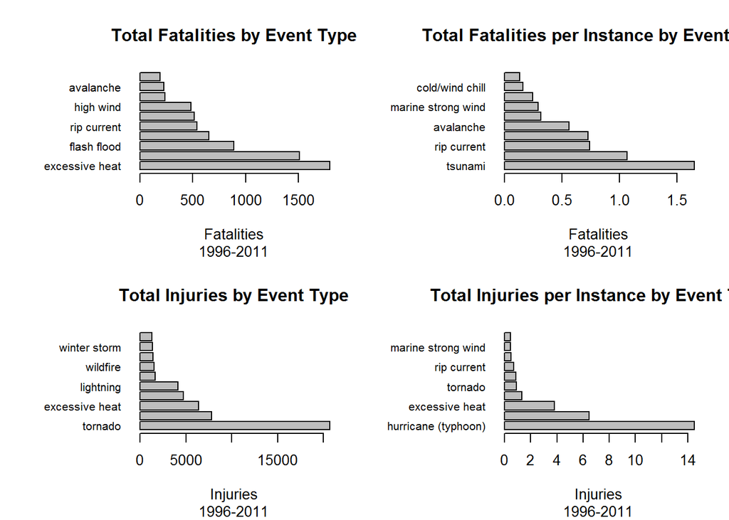

Figure 1

```r
#Bar plots of 10 most fatal and 10 most injurious Eventtypes

par(mfrow = c(2,2), #sets a 2x2 grid of plots
    las = 1, #can use to make labels vertical = 2
    mar = (c(5, 8, 4, 2)) # makes y margin larger (8, was 4)
  )
#Fatalities Total
eventsFat <- events
barplot(eventsFat$totFat[1:10],
        horiz = TRUE,
        main = "Total Fatalities by Event Type",
        sub = "1996-2011",
        names.arg = eventsFat$lookup[1:10],
        cex.names=0.8, xlab = "Fatalities")

#Fatalities per instance
eventsFatInst <- arrange(events, -(totFat/instances))
barplot(eventsFatInst$totFat[1:10]/eventsFatInst$instances[1:10],
        horiz = TRUE,
        main = "Total Fatalities per Instance by Event Type",
        sub = "1996-2011",
        names.arg = eventsFatInst$lookup[1:10],
        cex.names=0.8,  xlab = "Fatalities")

#Injuries Total
eventsInjur <- arrange(events, -totInjur)
barplot(eventsInjur$totInjur[1:10],
        horiz = TRUE,
        main = "Total Injuries by Event Type",
        sub = "1996-2011",
        names.arg = eventsInjur$lookup[1:10],
        cex.names=0.8,  xlab = "Injuries")

#Injuries per Instance
eventsInjurInst <- arrange(events, -(totInjur/instances))
barplot(eventsInjurInst$totInjur[1:10]/eventsInjurInst$instances[1:10],
        horiz = TRUE,
        main = "Total Injuries per Instance by Event Type",
        sub = "1996-2011",
        names.arg = eventsInjurInst$lookup[1:10],
        cex.names=.8, xlab = "Injuries")
```

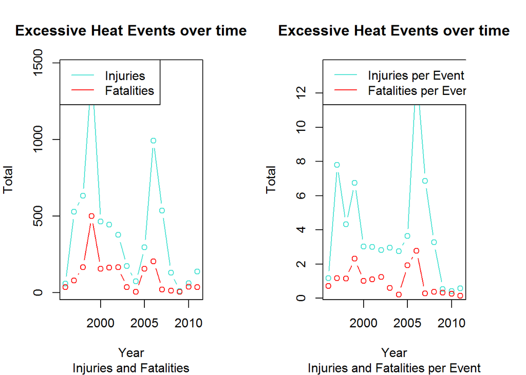

Figure 2

```r
#Excessive Heat Events over time

par( mfrow = c(1,2), mar = (c(5, 4, 4, 4))) #make right mrgin slightly larger

heat <- filter(yearsEvent, lookup == "excessive heat") %>% arrange(Year)
plot(heat$Year, heat$totInjur,
     type = "b", col = "turquoise",
     xlab = "Year", ylab = "Total",
     main  = "Excessive Heat Events over time",
     sub = "Injuries and Fatalities")
lines(heat$Year, heat$totFat, type = "b", col = "red")
legend("topleft", legend = c("Injuries", "Fatalities"), col = c("turquoise", "red"), lty = 1)
plot(heat$Year, heat$totInjur/heat$instances,
     type = "b", col = "turquoise",
     xlab = "Year", ylab = "Total",
     main = "Excessive Heat Events over time",
     sub = "Injuries and Fatalities per Event")
lines(heat$Year, heat$totFat/heat$instances, type = "b", col = "red")
legend("topleft", legend = c("Injuries per Event", "Fatalities per Event"), col = c("turquoise", "red"), lty = 1)
```

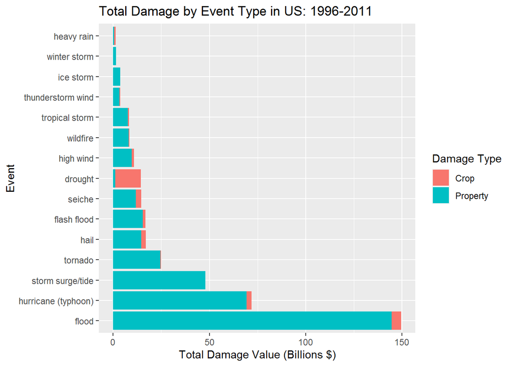

Figure 3

```r
#Graph of the top 20 total Damage events
etall <- events %>% arrange(-(totCropDam + totPropDam)) #Order Events by total Damage
etall <- etall[1:15,] %>% select(lookup, totCropDam, totPropDam) %>% #Select only Dam columns
        gather(key = "damType", value = "damValue", -lookup) %>% #Convert to a tall table
        mutate(damValueBill = damValue/1000000000)#Convert to Billions

ggplot() +
  geom_bar(data = etall, aes(x= reorder(lookup, -damValueBill), y = damValueBill, fill = damType), stat= "identity") +
  coord_flip()+
  labs(x = "Event", y = "Total Damage Value (Billions $)", title = "Total Damage by Event Type in US: 1996-2011") +
  scale_fill_discrete(name = "Damage Type", labels = c("Crop", "Property"))
```